# Project 2 : Healthcare

- DESCRIPTION

#### Problem Statement

- NIDDK (National Institute of Diabetes and Digestive and Kidney Diseases) research creates knowledge about and treatments for the most chronic, costly, and consequential diseases.
- The dataset used in this project is originally from NIDDK. The objective is to predict whether or not a patient has diabetes, based on certain diagnostic measurements included in the dataset.
- Build a model to accurately predict whether the patients in the dataset have diabetes or not.

#### Dataset Description

- The datasets consists of several medical predictor variables and one target variable (Outcome). Predictor variables includes the number of pregnancies the patient has had, their BMI, insulin level, age, and more.

| Variables |  | Description |
| --- | --- | --- |
| Pregnancies |  | Number of times pregnant **Numeric** |
| Glucose |  | Plasma glucose concentration in an oral glucose tolerance test **Numeric** |
| BloodPressure |  | Diastolic blood pressure (mm Hg) **Numeric** |
| SkinThickness |  | Triceps skinfold thickness (mm) **Numeric** |
| Insulin |  | Two hour serum insulin **Numeric** |
| BMI |  | Body Mass Index **Numeric** |
| DiabetesPedigreeFunction |  | Diabetes pedigree function **Numeric** |
| Age |  | Age in years **Numeric** |
| Outcome |  | Class variable (either 0 or 1). 268 of 768 values are 1, and the others are 0 |

### Week 1 Task

- Perform descriptive analysis. Understand the variables and their corresponding values. On the columns below, a value of zero does not make sense and thus indicates missing value: 1)Glucose 2)BloodPressure 3)SkinThickness 4)Insulin 5)BMI
- Visually explore these variables using histograms. Treat the missing values accordingly.
- There are integer and float data type variables in this dataset. Create a count (frequency) plot describing the data types and the count of variables.

```python
# Importing necessary libraries
import numpy as np
import pandas as pd
import matplotlib.pyplot as plt
import seaborn as sns
```

```python
healthcare_data = pd.read_csv("health care diabetes.csv")
healthcare_data.head()
```

|  | Pregnancies | Glucose | BloodPressure | SkinThickness | Insulin | BMI | DiabetesPedigreeFunction | Age | Outcome |
| --- | --- | --- | --- | --- | --- | --- | --- | --- | --- |
| 0 | 6 | 148 | 72 | 35 | 0 | 33.6 | 0.627 | 50 | 1 |
| 1 | 1 | 85 | 66 | 29 | 0 | 26.6 | 0.351 | 31 | 0 |
| 2 | 8 | 183 | 64 | 0 | 0 | 23.3 | 0.672 | 32 | 1 |
| 3 | 1 | 89 | 66 | 23 | 94 | 28.1 | 0.167 | 21 | 0 |
| 4 | 0 | 137 | 40 | 35 | 168 | 43.1 | 2.288 | 33 | 1 |

```python
healthcare_data.count() # Total 768 rows are present in the dataset.
healthcare_data.shape   # (768, 9) shape of the data.
```

```
(768, 9)
```

```python
healthcare_data.describe() # description of the all features in dataset.
```

|  | Pregnancies | Glucose | BloodPressure | SkinThickness | Insulin | BMI | DiabetesPedigreeFunction | Age | Outcome |
| --- | --- | --- | --- | --- | --- | --- | --- | --- | --- |
| count | 768.000000 | 768.000000 | 768.000000 | 768.000000 | 768.000000 | 768.000000 | 768.000000 | 768.000000 | 768.000000 |
| mean | 3.845052 | 120.894531 | 69.105469 | 20.536458 | 79.799479 | 31.992578 | 0.471876 | 33.240885 | 0.348958 |
| std | 3.369578 | 31.972618 | 19.355807 | 15.952218 | 115.244002 | 7.884160 | 0.331329 | 11.760232 | 0.476951 |
| min | 0.000000 | 0.000000 | 0.000000 | 0.000000 | 0.000000 | 0.000000 | 0.078000 | 21.000000 | 0.000000 |
| 25% | 1.000000 | 99.000000 | 62.000000 | 0.000000 | 0.000000 | 27.300000 | 0.243750 | 24.000000 | 0.000000 |
| 50% | 3.000000 | 117.000000 | 72.000000 | 23.000000 | 30.500000 | 32.000000 | 0.372500 | 29.000000 | 0.000000 |
| 75% | 6.000000 | 140.250000 | 80.000000 | 32.000000 | 127.250000 | 36.600000 | 0.626250 | 41.000000 | 1.000000 |
| max | 17.000000 | 199.000000 | 122.000000 | 99.000000 | 846.000000 | 67.100000 | 2.420000 | 81.000000 | 1.000000 |

```python
healthcare_data.dtypes
```

```
Pregnancies                   int64
Glucose                       int64
BloodPressure                 int64
SkinThickness                 int64
Insulin                       int64
BMI                         float64
DiabetesPedigreeFunction    float64
Age                           int64
Outcome                       int64
dtype: object
```

[output not shown]

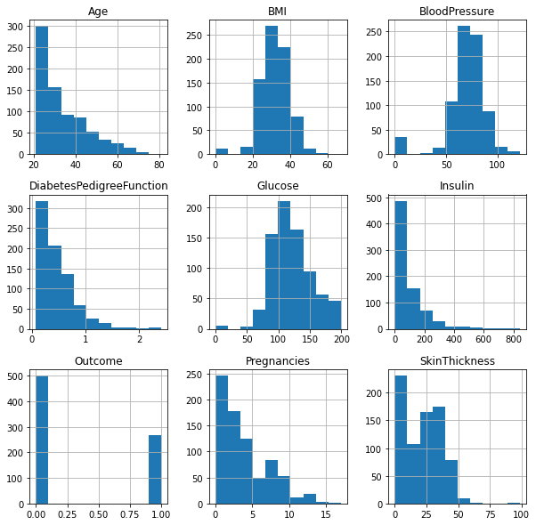

```python
healthcare_data.hist(figsize=(10,10))
```

```python
healthcare_data.isnull().sum()
```

```
Pregnancies                 0
Glucose                     0
BloodPressure               0
SkinThickness               0
Insulin                     0
BMI                         0
DiabetesPedigreeFunction    0
Age                         0
Outcome                     0
dtype: int64
```

**Note:** 0 value present in Gluscose,bloodpressure,skinthickness,insulin,BMI doesn't make sense. We will replace this 0 with median of the particular column.

```python
# Missing values treatment
healthcare_data['Glucose']=healthcare_data['Glucose'].replace(0,healthcare_data['Glucose'].median())
healthcare_data['BloodPressure']=healthcare_data['BloodPressure'].replace(0,healthcare_data['BloodPressure'].median())
healthcare_data['SkinThickness']=healthcare_data['SkinThickness'].replace(0,healthcare_data['SkinThickness'].median())
healthcare_data['Insulin']=healthcare_data['Insulin'].replace(0,healthcare_data['Insulin'].median())
healthcare_data['BMI']=healthcare_data['BMI'].replace(0,healthcare_data['BMI'].median())
```

```python
healthcare_data.head(10) # missing value treatment done successfully.
```

|  | Pregnancies | Glucose | BloodPressure | SkinThickness | Insulin | BMI | DiabetesPedigreeFunction | Age | Outcome |
| --- | --- | --- | --- | --- | --- | --- | --- | --- | --- |
| 0 | 6 | 148 | 72 | 35 | 30.5 | 33.6 | 0.627 | 50 | 1 |
| 1 | 1 | 85 | 66 | 29 | 30.5 | 26.6 | 0.351 | 31 | 0 |
| 2 | 8 | 183 | 64 | 23 | 30.5 | 23.3 | 0.672 | 32 | 1 |
| 3 | 1 | 89 | 66 | 23 | 94.0 | 28.1 | 0.167 | 21 | 0 |
| 4 | 0 | 137 | 40 | 35 | 168.0 | 43.1 | 2.288 | 33 | 1 |
| 5 | 5 | 116 | 74 | 23 | 30.5 | 25.6 | 0.201 | 30 | 0 |
| 6 | 3 | 78 | 50 | 32 | 88.0 | 31.0 | 0.248 | 26 | 1 |
| 7 | 10 | 115 | 72 | 23 | 30.5 | 35.3 | 0.134 | 29 | 0 |
| 8 | 2 | 197 | 70 | 45 | 543.0 | 30.5 | 0.158 | 53 | 1 |
| 9 | 8 | 125 | 96 | 23 | 30.5 | 32.0 | 0.232 | 54 | 1 |

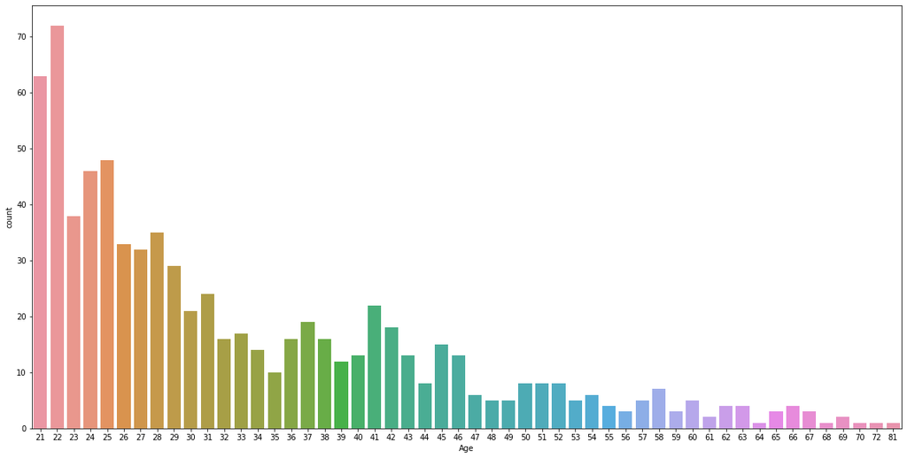

```python
#Create a count (frequency) plot describing the data types and the count of variables.
plt.figure(figsize=(20,10))
sns.countplot(x='Age',data=healthcare_data)
```

### Project Task: Week 2

#### Data Exploration:

1. Check the balance of the data by plotting the count of outcomes by their value. Describe your findings and plan future course of action.
2. Create scatter charts between the pair of variables to understand the relationships. Describe your findings.
3. Perform correlation analysis. Visually explore it using a heat map.

```python
healthcare_data.dtypes
```

```
Pregnancies                   int64
Glucose                       int64
BloodPressure                 int64
SkinThickness                 int64
Insulin                     float64
BMI                         float64
DiabetesPedigreeFunction    float64
Age                           int64
Outcome                       int64
dtype: object
```

**observation** :Here the **Outcome** is numeric we will convert this into categorical.

```python
healthcare_data['Outcome']=pd.Categorical(healthcare_data['Outcome'])
```

```
0    500
1    268
Name: Outcome, dtype: int64
```

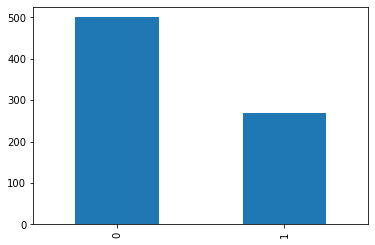

```python
# Check the balance of the data by plotting the count of outcomes by their value. Describe your findings
print(healthcare_data['Outcome'].value_counts())
healthcare_data['Outcome'].value_counts().plot.bar();
```

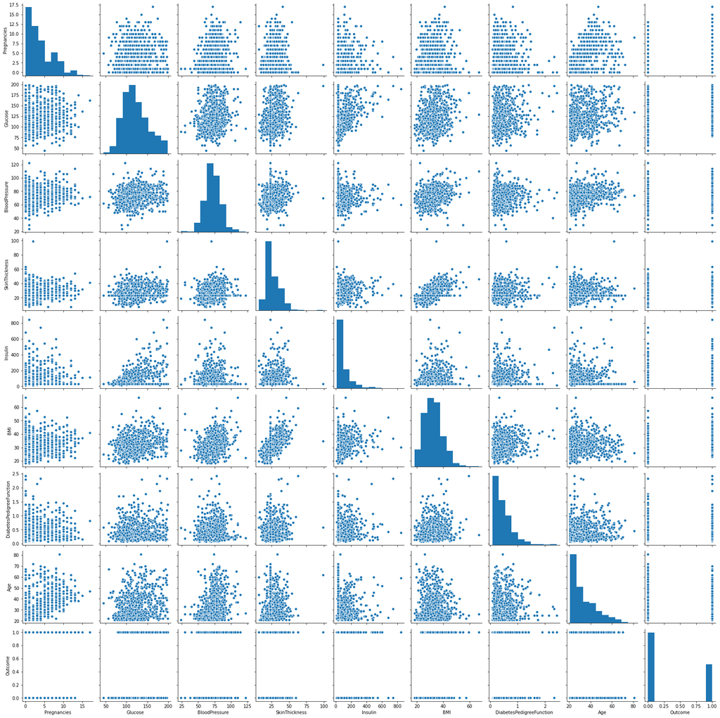

```python
# Create scatter charts between the pair of variables to understand the relationships. Describe your findings.
sns.pairplot(healthcare_data,palette='hue')
```

```python
#Perform correlation analysis. Visually explore it using a heat map.
healthcare_data.corr()
```

|  | Pregnancies | Glucose | BloodPressure | SkinThickness | Insulin | BMI | DiabetesPedigreeFunction | Age |
| --- | --- | --- | --- | --- | --- | --- | --- | --- |
| Pregnancies | 1.000000 | 0.128213 | 0.208615 | 0.032568 | -0.055697 | 0.021546 | -0.033523 | 0.544341 |
| Glucose | 0.128213 | 1.000000 | 0.218937 | 0.172143 | 0.357573 | 0.231400 | 0.137327 | 0.266909 |
| BloodPressure | 0.208615 | 0.218937 | 1.000000 | 0.147809 | -0.028721 | 0.281132 | -0.002378 | 0.324915 |
| SkinThickness | 0.032568 | 0.172143 | 0.147809 | 1.000000 | 0.238188 | 0.546951 | 0.142977 | 0.054514 |
| Insulin | -0.055697 | 0.357573 | -0.028721 | 0.238188 | 1.000000 | 0.189022 | 0.178029 | -0.015413 |
| BMI | 0.021546 | 0.231400 | 0.281132 | 0.546951 | 0.189022 | 1.000000 | 0.153506 | 0.025744 |
| DiabetesPedigreeFunction | -0.033523 | 0.137327 | -0.002378 | 0.142977 | 0.178029 | 0.153506 | 1.000000 | 0.033561 |
| Age | 0.544341 | 0.266909 | 0.324915 | 0.054514 | -0.015413 | 0.025744 | 0.033561 | 1.000000 |

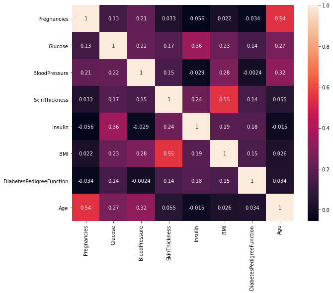

```python
plt.figure(figsize=(10,8))
sns.heatmap(healthcare_data.corr(),annot=True)
```

**Observation :** There is no strong linear relation in between the feature variables.

### Project Task: Week 3

#### Data Modeling:

1. Devise strategies for model building. It is important to decide the right validation framework. Express your thought process.
2. Apply an appropriate classification algorithm to build a model. Compare various models with the results from KNN algorithm.
3. Data Modeling: Create a classification report by analyzing sensitivity, specificity, AUC (ROC curve), etc. Please be descriptive to explain what values of these parameter you have used.

#### Devise strategies for model building. It is important to decide the right validation framework. Express your thought process.

```python
# divide the data
X=healthcare_data.drop('Outcome',axis=1)
y=healthcare_data['Outcome']
```

```python
# train test split
from sklearn.model_selection import train_test_split
X_train,X_test,y_train,y_test = train_test_split(X,y,test_size=0.2,random_state=21)
```

```python
print(X_train.shape)
print(X_test.shape)
print(y_train.shape)
print(y_test.shape)
```

```
(614, 8)
(154, 8)
(614,)
(154,)
```

```python
#Apply an appropriate classification algorithm to build a model. Compare various models with the results from KNN algorithm.
from sklearn.neighbors import KNeighborsClassifier
knn_model = KNeighborsClassifier(n_neighbors=4)
knn_model.fit(X_train,y_train)
```

```
KNeighborsClassifier(n_neighbors=4)
```

```python
# prediction from training and the testing data to know model accuracy
knn_y_pred_train= knn_model.predict(X_train)
knn_y_pred_test = knn_model.predict(X_test)
```

```python
# Check whether the model is overfitted,underfitted or it is appropriate
from sklearn.metrics import accuracy_score,classification_report
print('The accuracy of the training model is :',accuracy_score(y_train,knn_y_pred_train))
print('The accuracy of the testing model is :',accuracy_score(y_test,knn_y_pred_test))
```

```
The accuracy of the training model is : 0.8143322475570033
The accuracy of the testing model is : 0.6688311688311688
```

```python
print(classification_report(y_test,knn_y_pred_test))
```

```
              precision    recall  f1-score   support

           0       0.66      0.93      0.77        94
           1       0.70      0.27      0.39        60

    accuracy                           0.67       154
   macro avg       0.68      0.60      0.58       154
weighted avg       0.68      0.67      0.62       154
```

### Using Logistic Regression

```python
from sklearn.linear_model import LogisticRegression
log_model = LogisticRegression()
log_model.fit(X_train,y_train)
```

```
LogisticRegression()
```

```python
# prediction from training and the testing data to know model accuracy
log_y_pred_train= log_model.predict(X_train)
log_y_pred_test = log_model.predict(X_test)
```

```python
print('The accuracy of the training model is :',accuracy_score(y_train,log_y_pred_train))
print('The accuracy of the testing model is :',accuracy_score(y_test,log_y_pred_test))
```

```
The accuracy of the training model is : 0.7915309446254072
The accuracy of the testing model is : 0.7402597402597403
```

```python
print(classification_report(y_test,log_y_pred_test))
```

```
              precision    recall  f1-score   support

           0       0.73      0.90      0.81        94
           1       0.76      0.48      0.59        60

    accuracy                           0.74       154
   macro avg       0.75      0.69      0.70       154
weighted avg       0.74      0.74      0.72       154
```

**Observation :** Training accuracy of knn is higher than logistic but testing accuracy of logistic is greater than knn.

### Using Decision Tree

```python
from sklearn.tree import DecisionTreeClassifier
dec_model = DecisionTreeClassifier()
dec_model.fit(X_train,y_train)
```

```
DecisionTreeClassifier()
```

```python
# prediction from training and the testing data to know model accuracy
dec_y_pred_train= dec_model.predict(X_train)
dec_y_pred_test = dec_model.predict(X_test)
```

```python
print('The accuracy of the training model is :',accuracy_score(y_train,dec_y_pred_train))
print('The accuracy of the testing model is :',accuracy_score(y_test,dec_y_pred_test))
```

```
The accuracy of the training model is : 1.0
The accuracy of the testing model is : 0.7012987012987013
```

```python
print(classification_report(y_test,dec_y_pred_test))
```

```
              precision    recall  f1-score   support

           0       0.74      0.79      0.76        94
           1       0.63      0.57      0.60        60

    accuracy                           0.70       154
   macro avg       0.68      0.68      0.68       154
weighted avg       0.70      0.70      0.70       154
```

**Observation :** Here both training and testing accuracy is greator than knn.

### Using Random forest

```python
from sklearn.ensemble import RandomForestClassifier
ref_model = RandomForestClassifier(n_estimators=150)
ref_model.fit(X_train,y_train)
```

```
RandomForestClassifier(n_estimators=150)
```

```python
# prediction from training and the testing data to know model accuracy
ref_y_pred_train= ref_model.predict(X_train)
ref_y_pred_test = ref_model.predict(X_test)
```

```python
print('The accuracy of the training model is :',accuracy_score(y_train,ref_y_pred_train))
print('The accuracy of the testing model is :',accuracy_score(y_test,ref_y_pred_test))
```

```
The accuracy of the training model is : 1.0
The accuracy of the testing model is : 0.7402597402597403
```

```python
print(classification_report(y_test,ref_y_pred_test))
```

```
              precision    recall  f1-score   support

           0       0.73      0.91      0.81        94
           1       0.78      0.47      0.58        60

    accuracy                           0.74       154
   macro avg       0.75      0.69      0.70       154
weighted avg       0.75      0.74      0.72       154
```

## Hyperparameter tunning

```python
from sklearn.model_selection import RandomizedSearchCV
Ran_ref_model = RandomForestClassifier()
```

```python
n_estimators= [int(x) for x in np.linspace(100,1000,10)]
criterion=["gini", "entropy"]
max_depth=[4,5,6]
min_samples_split=[2,3,4]
min_samples_leaf=[1,2,3]
```

```python
param = {'n_estimators':n_estimators,'criterion':criterion,'max_depth':max_depth,'min_samples_split':min_samples_split,'min_samples_leaf':min_samples_leaf}
```

```python
ran_ref_final_model = RandomizedSearchCV(Ran_ref_model,param_distributions=param,n_iter=50,cv=4,n_jobs=-1,verbose=1)
ran_ref_final_model.fit(X_train,y_train)
```

```
Fitting 4 folds for each of 50 candidates, totalling 200 fits
```

```
[Parallel(n_jobs=-1)]: Using backend LokyBackend with 4 concurrent workers.
[Parallel(n_jobs=-1)]: Done  42 tasks      | elapsed:   18.7s
[Parallel(n_jobs=-1)]: Done 192 tasks      | elapsed:  1.4min
[Parallel(n_jobs=-1)]: Done 200 out of 200 | elapsed:  1.5min finished
```

```
RandomizedSearchCV(cv=4, estimator=RandomForestClassifier(), n_iter=50,
                   n_jobs=-1,
                   param_distributions={'criterion': ['gini', 'entropy'],
                                        'max_depth': [4, 5, 6],
                                        'min_samples_leaf': [1, 2, 3],
                                        'min_samples_split': [2, 3, 4],
                                        'n_estimators': [100, 200, 300, 400,
                                                         500, 600, 700, 800,
                                                         900, 1000]},
                   verbose=1)
```

```python
ran_ref_final_model.best_estimator_
```

```
RandomForestClassifier(max_depth=6, min_samples_leaf=3, min_samples_split=3,
                       n_estimators=500)
```

```python
# prediction from training and the testing data to know model accuracy
ran_ref_y_pred_train= ran_ref_final_model.predict(X_train)
ran_ref_y_pred_test = ran_ref_final_model.predict(X_test)
```

```python
print('The accuracy of the training model is :',accuracy_score(y_train,ran_ref_y_pred_train))
print('The accuracy of the testing model is :',accuracy_score(y_test,ran_ref_y_pred_test))
```

```
The accuracy of the training model is : 0.8583061889250815
The accuracy of the testing model is : 0.7402597402597403
```

```python
print(classification_report(y_test,ran_ref_y_pred_test))
```

```
              precision    recall  f1-score   support

           0       0.73      0.91      0.81        94
           1       0.78      0.47      0.58        60

    accuracy                           0.74       154
   macro avg       0.75      0.69      0.70       154
weighted avg       0.75      0.74      0.72       154
```

#### Data Modeling: Create a classification report by analyzing sensitivity, specificity, AUC (ROC curve), etc. Please be descriptive to explain what values of these parameter you have used.

```python
from sklearn.metrics import roc_curve,roc_auc_score
# Taking prediction probability from every model to calculate fpr,tpr,threshold values to draw roc curve
y_knn_pred = knn_model.predict_proba(X_test)[:,1]
y_log_pred = log_model.predict_proba(X_test)[:,1]
y_dec_pred = dec_model.predict_proba(X_test)[:,1]
y_ranfor_pred = ran_ref_final_model.predict_proba(X_test)[:,1]
```

```python
# calculation of fpr(False positive rate), tpr(True positive rate) values for every model
fpr_knn,tpr_knn,threshold_knn = roc_curve(y_test,y_knn_pred,drop_intermediate=False)
fpr_log,tpr_log,threshold_log = roc_curve(y_test,y_log_pred,drop_intermediate=False)
fpr_dec,tpr_dec,threshold_dec = roc_curve(y_test,y_dec_pred,drop_intermediate=False)
fpr_ran,tpr_ran,threshold_ran = roc_curve(y_test,y_ranfor_pred,drop_intermediate=False)
```

```python
# Calculating AUC values for every model
auc_knn = roc_auc_score(y_test,y_knn_pred)
auc_log = roc_auc_score(y_test,y_log_pred)
auc_dec = roc_auc_score(y_test,y_dec_pred)
auc_ran = roc_auc_score(y_test,y_ranfor_pred)
```

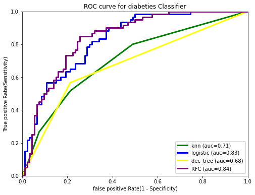

```python
# Plotting roc curve to check which model is gives higher accuracy,recall,precision
plt.figure(figsize=(8,6))
plt.xlim([0.0,1.0])
plt.ylim([0.0,1.0])
plt.title("ROC curve for diabeties Classifier")
plt.xlabel('false positive Rate(1 - Specificity)')
plt.ylabel("True positive Rate(Sensitivity)")
plt.plot(fpr_knn,tpr_knn,color='green',lw=3,label='knn (auc=%0.2f)' %auc_knn)
plt.plot(fpr_log,tpr_log,color='blue',lw=3,label='logistic (auc=%0.2f)'%auc_log)
plt.plot(fpr_dec,tpr_dec,color='yellow',lw=3,label='dec_tree (auc=%0.2f)' %auc_dec)
plt.plot(fpr_ran,tpr_ran,color='purple',lw=3,label='RFC (auc=%0.2f)'%auc_ran)
plt.legend()
plt.show()
```

**Observation** : from the above roc_auc curve we can say that for the above problem Logistic regression and random forest model gives us better output with auc score of 0.83 and 0.84 respectively

### Project Task: Week 4

#### Data Reporting:

1. Create a dashboard in tableau by choosing appropriate chart types and metrics useful for the business. The dashboard must entail the following:

a. Pie chart to describe the diabetic or non-diabetic population

b. Scatter charts between relevant variables to analyze the relationships

c. Histogram or frequency charts to analyze the distribution of the data

d. Heatmap of correlation analysis among the relevant variables

e. Create bins of these age values: 20-25, 25-30, 30-35, etc. Analyze different variables for these age brackets using a bubble chart.

```python
healthcare_data.to_csv(r'C:\Users\nisarg\Desktop\Data Science\Capstone Projects\Project 2\Healthcare - Diabetes\tableaufile.csv',index=False)
```

**Observation** : we have converted the file to csv for visualization purpose